# GGPLOT2 in R

2/8/2018

## Outline

- Why ggplot2
- Component of Grammar of Graphic
- Basic Structure
- Construct Plot Layer by Layer
- Scales, Position, Facets and Themes
- An Example

## Why ggplot2

- Grammar of graphic
- Both quick and complex plot
- Easy to "create" plot
- Nice aesthetic settings
- Great docummentation and active mailing list

Things you cannot do:

- 3-dimensional graphics (rgl)
- Interactive graphics (ggvis, plotly)

## Components of Grammar of Graphic

- **Data** that you want to visualise and a set of aesthetic mappings describing how variables in the data are mapped to aesthetic attributes.
- **Layers** made up of geometric elements and statistical transformation. Geometric objects, **geoms** for short, such as points, lines, polygons, etc. Statistical transformations, **stats** for short, summarise data in many useful ways, such as, histogram and summarising a 2d relationship with a linear model.
- The **scales** map values in the data space to values in an aesthetic space, whether it be colour, or size, or shape.
- A **coordinate system**, coord for short, describes how data coordinates are mapped to the plane of the graphic.
- A **facet** describes how to break up the data into subsets and how to display those subsets as small multiples.
- A **theme** which controls the finer points of display, like the font size and background colour.

## Data Frame

- [2017 Airbnb data of New York City](http://insideairbnb.com/get-the-data.html)
- 43234 observations and 16 variables
- It consists of features of each Airbnb room in NYC such as price, review per month, name of neighbourhood, name of borough, latitude and longitude
- Simple cleansing

## Structure of ggplot

ggplot(data, aes(x = ,y = )) + layers + additional elements

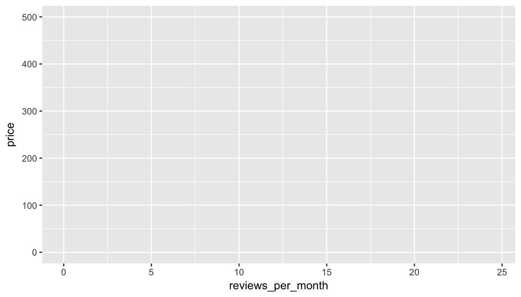

```r
ggplot(Airbnb, aes(x = reviews_per_month, y = price))
```

## Add a layer

- Display the data or the statistical summaries of the data
- Mainly use geom_xxx() function
- An alternative way is stat_xxx() function
- A plot must have at least one geom or stat function. there is no upper limit. You can add a layer to a plot using the + operator
- All kinds of geom function and stat function: [ggplot2 cheat sheet](https://www.rstudio.com/wp-content/uploads/2015/03/ggplot2-cheatsheet.pdf)

## Geom_xxx()

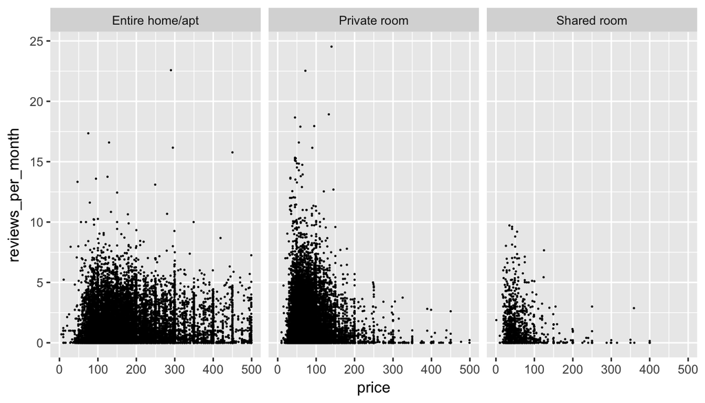

```r
ggplot(Airbnb, aes(price, reviews_per_month)) +
  geom_point(size = 0.1) +
  facet_grid(~room_type)
```

## Aesthetic Mapping

- Describe how variables are mapped to visual properties
- aes()
- Specifying the Aesthetics in the Plot(ggplot()) or in the Layers(geom_xxx() or stat_xxx())
- Aesthetic Mapping can consists of Position (i.e., on the x and y axes), color (“outside” color), fill (“inside” color), shape (of points), linetype and size, etc.

## Aesthetic Mapping

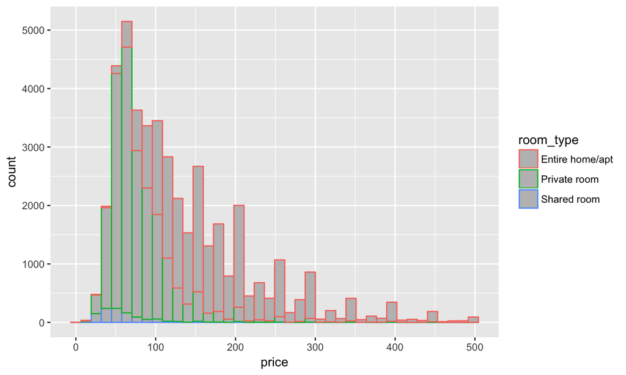

```r
ggplot(Airbnb, aes(x = price)) +
  geom_histogram(bins = 40, aes(color = room_type), fill = "grey")
```

## Aesthetic Mapping

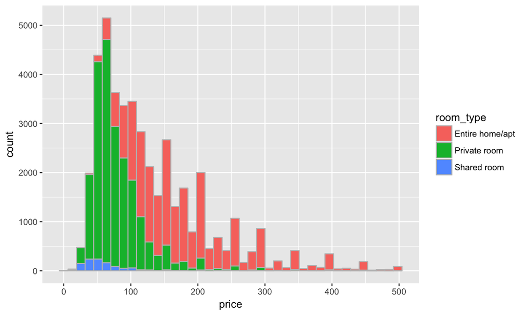

```r
ggplot(Airbnb, aes(x = price)) +
  geom_histogram(bins = 40, aes(fill = room_type), color = "grey")
```

## Construct Plot Layer by Layer

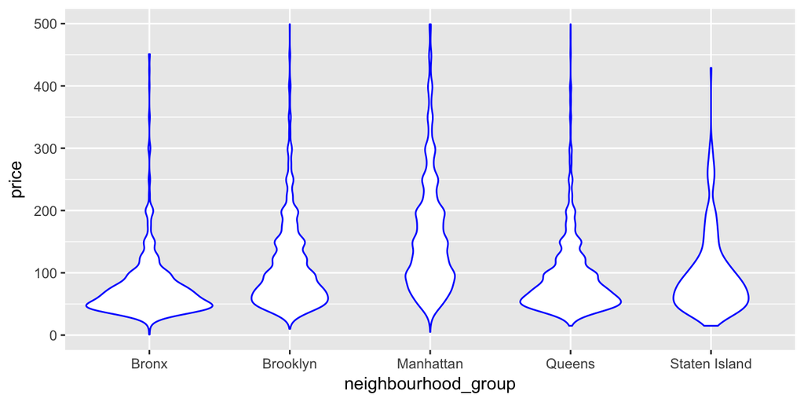

```r
ggplot(Airbnb) +
  geom_violin(aes(neighbourhood_group, price), colour = 'blue')
```

## Construct Plot Layer by Layer

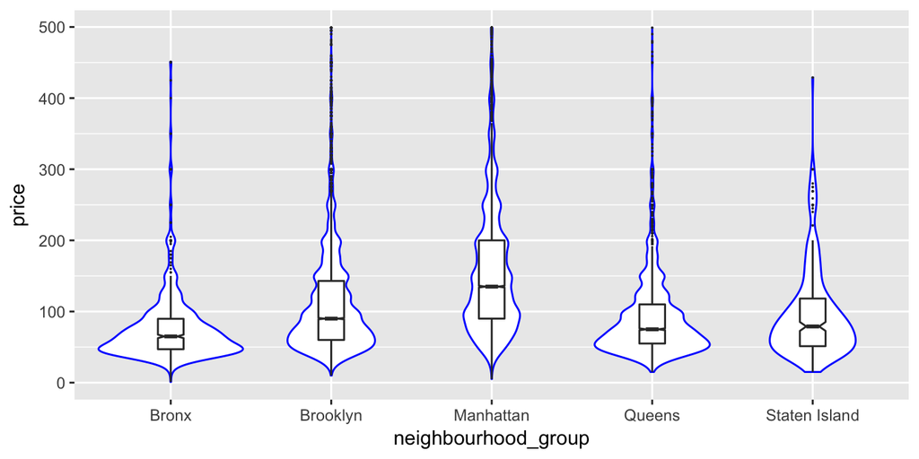

```r
ggplot(Airbnb) +
  geom_violin(aes(neighbourhood_group, price), colour = 'blue') +
  geom_boxplot(aes(neighbourhood_group, price), width = 0.16,
               outlier.size = 0, notch = TRUE)
```

## Scales

- Controls the mapping from data to aesthetic
- Include position, color and fill, size, shape and line type

Available Scales

| Scale | Example |
| --- | --- |
| scale_color_ | scale_color_gradient |
| scale_fill_ | scale_fill_discrete |
| scale_size_ | scale_size_manual |
| scale_shape_ | scale_shape_discrete |
| scale_linetype_ | scale_linetype_manual |
| scale_x_ | scale_x_continuous |
| scale_y_ | scale_y_reverse |

## Scale Modification Example

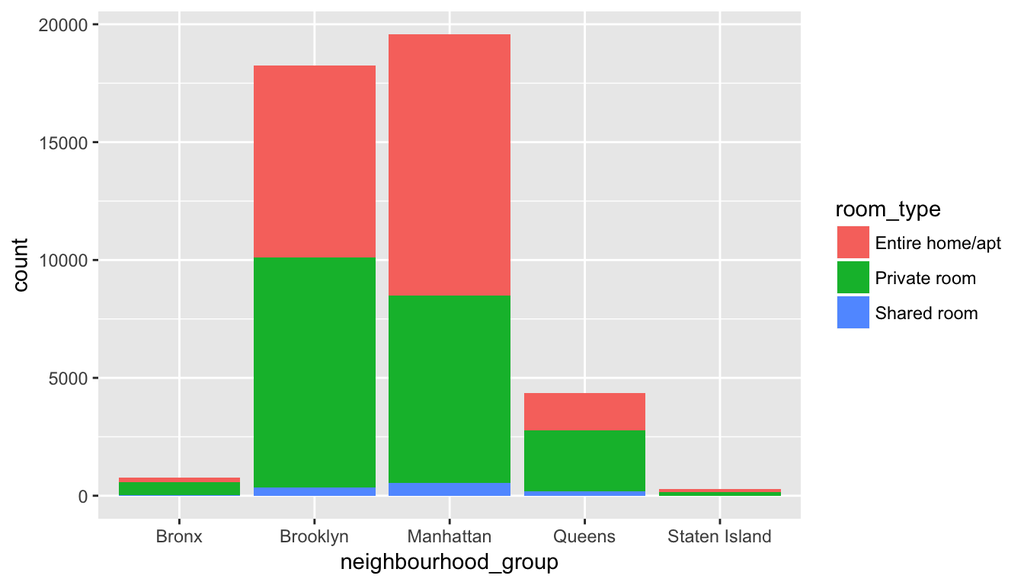

```r
w1 <- ggplot(Airbnb) +
  geom_bar(aes(x = neighbourhood_group, fill = room_type))
w1
```

## Scale Modification Example

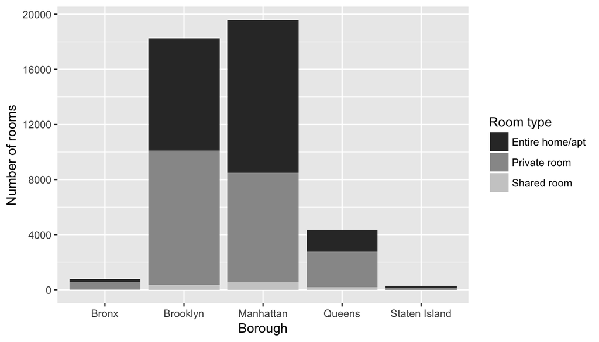

```r
w1 + scale_x_discrete(name = 'Borough') +
  scale_y_continuous(name = 'Number of rooms',
                     breaks = seq(0,20000,4000)) +
  scale_fill_grey(name = 'Room type')
```

## Theme

- Control appearance of non-data elements
- Titles, tick marks and labels
- Legends appearance
- Overall look
- theme()

## Facet

- Facetting generates small multiples each showing a different subset of the data.
- facet_grid() and facet_wrap()
- facet_grid() is fundamentally 2d, being made up of two independent components.
- facet_wrap() is 1d, but wrapped into 2d to save space

## Facet_wrap()

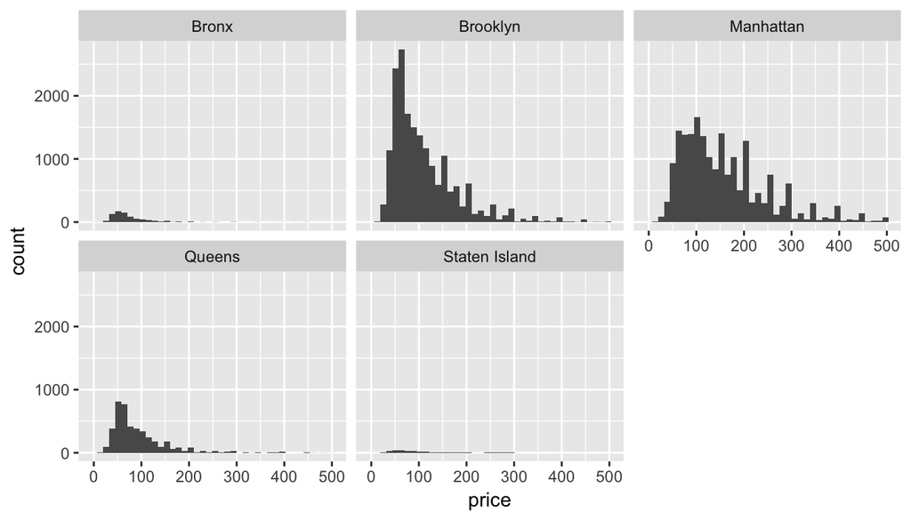

```r
ggplot(Airbnb, aes(price)) +
  geom_histogram(bins = 40) +
  facet_wrap(~neighbourhood_group)
```

## Facet_grid()

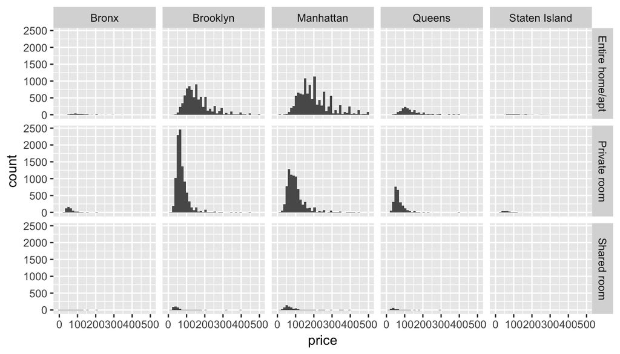

```r
ggplot(Airbnb, aes(price)) +
  geom_histogram(bins = 40) +
  facet_grid(room_type ~ neighbourhood_group)
```

## Putting All Things Together

How to construct this plot?

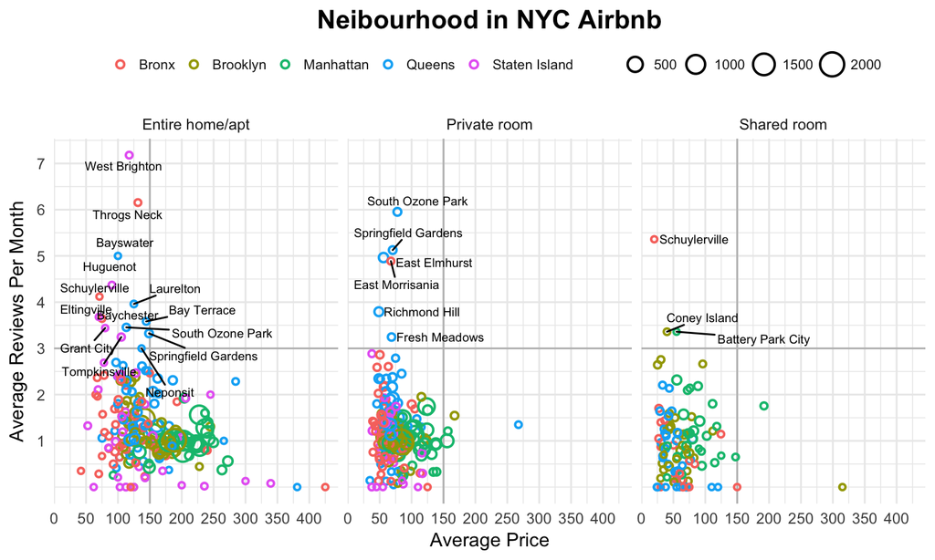

## Data Transformation

```r
Airbnb_sub1 <- aggregate(Airbnb[ ,c(10,14)],
  list(Airbnb$neighbourhood, Airbnb$neighbourhood_group,
       Airbnb$room_type), mean)
neighbourhood_count <- data.frame(table(Airbnb$neighbourhood,
                  Airbnb$neighbourhood_group, Airbnb$room_type))
neighbourhood_count <-
      neighbourhood_count[which(neighbourhood_count$Freq != 0), ]
Airbnb_sub2 <- merge(Airbnb_sub1, neighbourhood_count,
      by.x =c( 'Group.1', 'Group.2', 'Group.3'),
      by.y = c('Var1', 'Var2', 'Var3'), all.x = TRUE)
      names(Airbnb_sub2) <- c('neighbourhood', 'neighbourhood_group',
                'room_type', 'average_price', 'average_rpm', 'count')
good_neighbourhood <-
  subset(Airbnb_sub2, Airbnb_sub2$average_rpm >= 3)
good_neighbourhood <-
  subset(good_neighbourhood, good_neighbourhood$average_price <=150)
```

## Basic Scatterplot with three facets

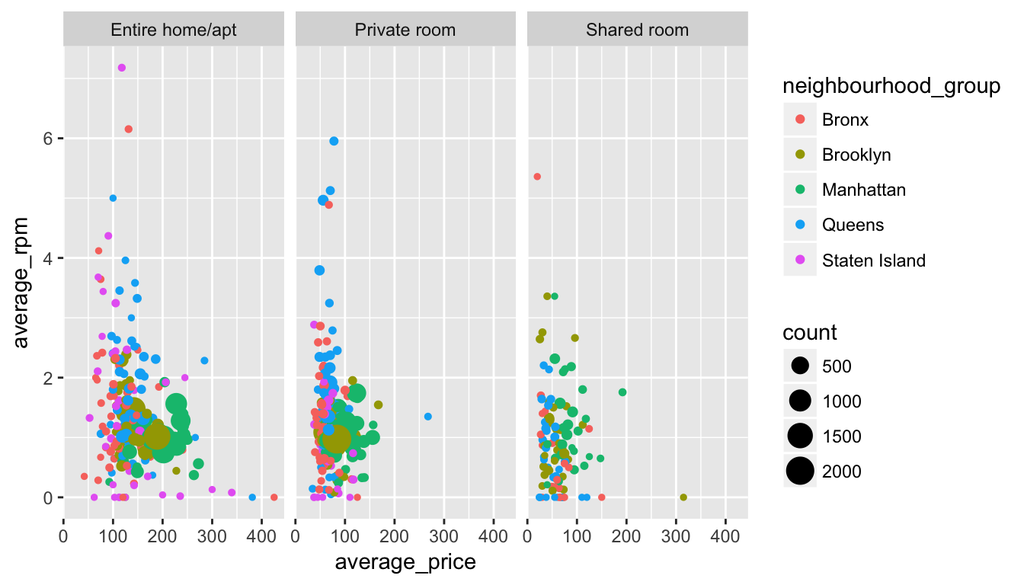

```r
p <- ggplot(Airbnb_sub2, aes(average_price, average_rpm)) +
  geom_point(aes(color = neighbourhood_group, size = count)) +
  facet_wrap(~room_type)
p
```

## What need we do?

- Change the point shape to open circle
- Add horizontal and vertical line
- Add name of those 'good neighbourhoods'
- Title, label axes, legend
- Change theme

## Change the point shape to open circle

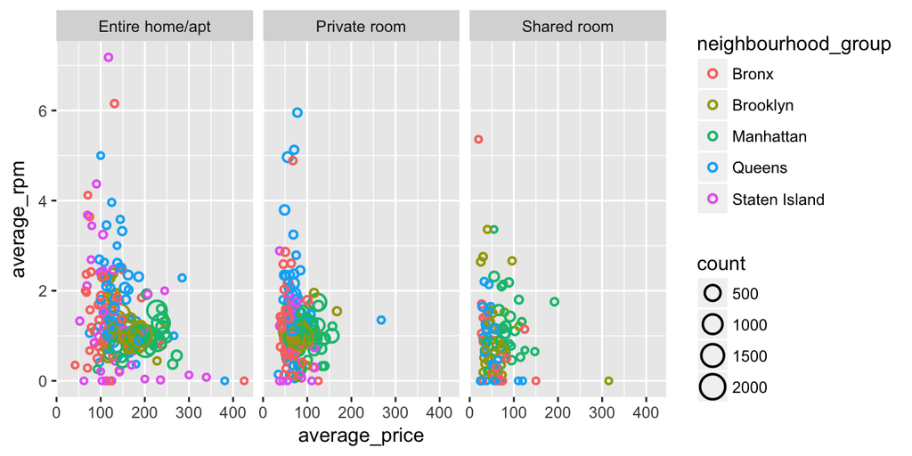

```r
p1 <- ggplot(Airbnb_sub2, aes(average_price, average_rpm)) +
  geom_point(aes(color = neighbourhood_group, size = count),
             shape = 1, stroke = 1) +
  facet_wrap(~room_type)
p1
```

## Add horizontal and vertical line

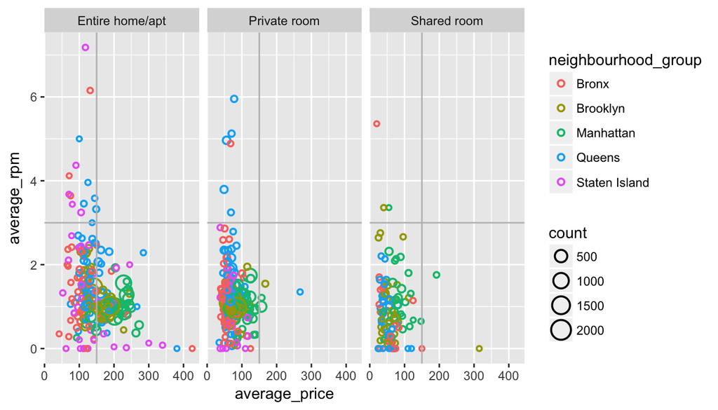

```r
p2<- p1 +  geom_vline(aes(xintercept = 150), color = 'grey') +
  geom_hline(aes(yintercept = 3), color = 'grey')
p2
```

## Add names of those 'good neighbourhoods'

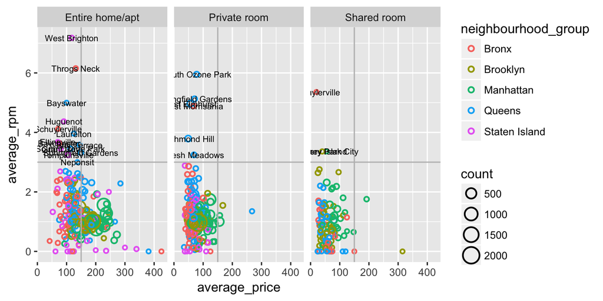

```r
p3 <- p2 + geom_text(aes(label = neighbourhood),
           data = good_neighbourhood, size = 2.5)
p3
```

## A better way to add those names

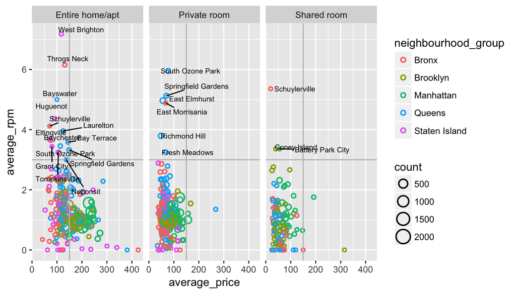

```r
library(ggrepel)
p3 <- p2 + geom_text_repel(aes(label = neighbourhood),
           data = good_neighbourhood, size = 2.5)
p3
```

## Change theme

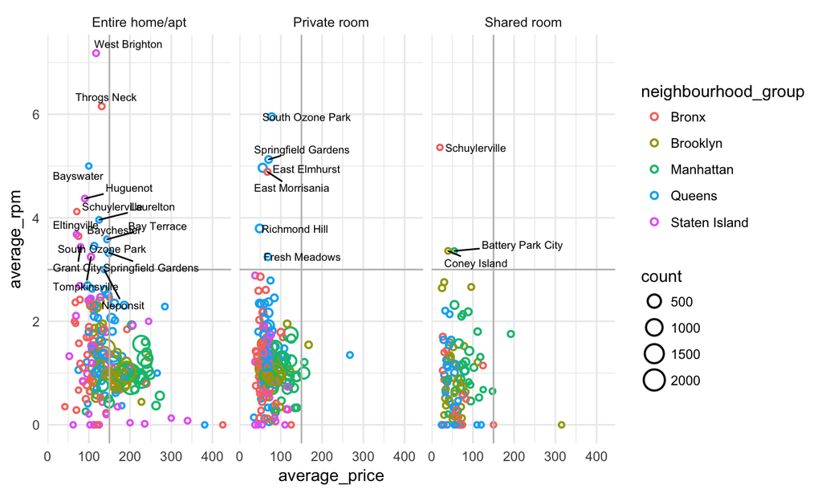

```r
p4 <- p3 + theme_minimal()
p4
```

## Title, label axes and legend

```r
p5 <- p4 +
  scale_x_continuous(name = 'Average Price',
                     breaks = seq(0, 400, 100)) +
  scale_y_continuous(name = 'Average Reviews Per Month',
                     breaks = c(1:8)) +
  scale_color_discrete(name = '') +
  scale_size_continuous(name = '') +
  labs(title = 'Neibourhood in NYC Airbnb') +
  theme(legend.position = 'top',
        legend.text = element_text(size = 8, color = 'gray10'),
    plot.title = element_text(size = 15, face = 'bold', hjust = 0.5))
```

## Title, label axes and legend

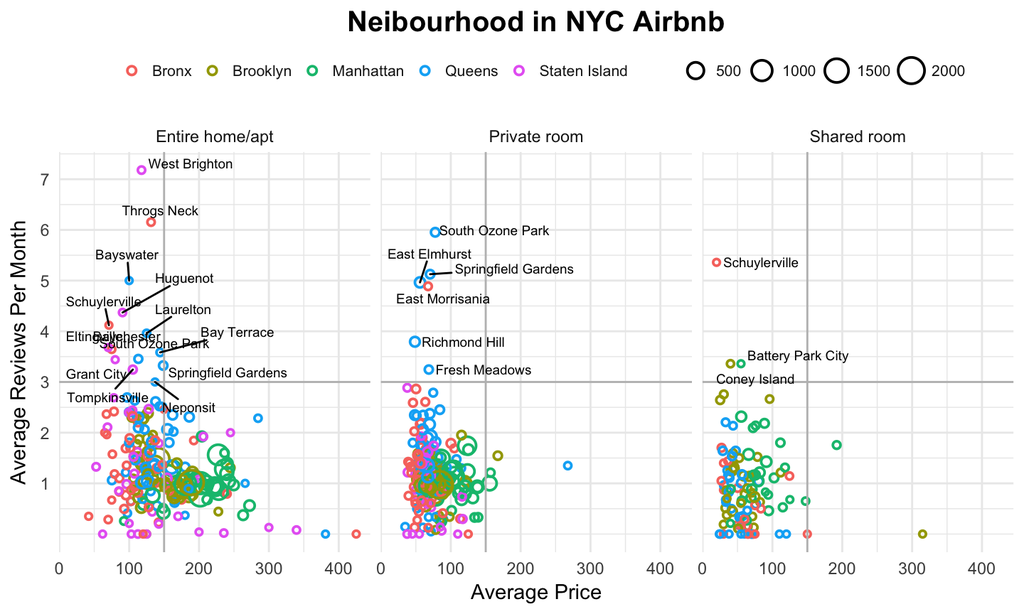

```r
p5
```

## Additional Resource

- Wickham, H. (2016). ggplot2: elegant graphics for data analysis. Springer.
- [ggplot2 cheat sheet](https://www.rstudio.com/wp-content/uploads/2015/03/ggplot2-cheatsheet.pdf)
- [ggplot2 workshop](http://tutorials.iq.harvard.edu/R/Rgraphics/Rgraphics.html#faceting)
- [Top 50 ggplot2 Visualizations](http://r-statistics.co/Top50-Ggplot2-Visualizations-MasterList-R-Code.html)

## Thank you for your audience!